# cycleRtools Workflow

## Correct Elevation Data

The barometric altimeters in GPS head-units are cannot always be trusted to provide accurate and(or) reliable topographical data. This package can *at least* generate *reliable* values via positional coordinates (if available):

```r
# When invoked for the first time, this requires an internet connection to
# download topographical data files (see ?download_elev_data). Package "raster"
# must also be installed.

cycling_data$.elevation.corrected.m <-
  elevation_correct(cycling_data, country = "GBR")
```

We can then compare the above:

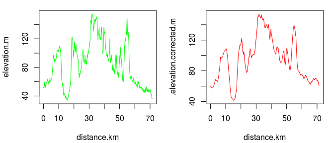

```r
par(mfrow = c(1, 2), mar = c(4.1, 4.1, 1.1, 1.1))
with(cycling_data, plot(x = distance.km,
                        y = elevation.m,
                        type = "l",
                        col = "green"))
with(cycling_data, plot(x = distance.km,
                        y = .elevation.corrected.m,
                        type = "l",
                        col = "red"))
```

Or, perhaps more usefully, plot the differences throughout the ride:

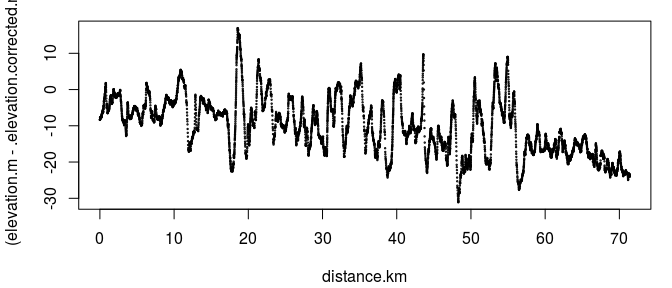

```r
par(mar = c(4.1, 4.1, 1.1, 1.1))
with(cycling_data, plot(x = distance.km,
                        y = (elevation.m - .elevation.corrected.m),
                        cex = 0.2))
```

## Extracting Best Averages

As cyclists, we are often most interested in gleaning our *“best”* power outputs for certain durations - e.g. best 20 minute power. In more mathematical terms, these are “maximum mean values”, or more specifically “maximum mean powers” (MMP, as they are often referred). Computationally, this amounts to identifying the maximum value of a rolling average. One issue that arises from this process is that efficient algorithms will roll over **row** windows, rather than **time** windows, the latter being of interest here. Hence the function `uniform()` was written to make rows of a data set uniform in terms of time, hence making row windows and time windows one in the same (see `?uniform`).

For the sake of example, let’s say we want to know the best 1, 5 and 20 minute powers for the present data:

```r
tsec <- c(1, 5, 20) * 60  # Time windows must be in units of seconds.
mmv(data    = cycling_data,
    windows = tsec,
    column  = power.W,
    verbose = FALSE)
```

[output not shown]

The function `mmv` (maximal mean values) returns a matrix object with two rows: the first row shows the actual best values; the second row states where in the data (start time; seconds) those values were recorded. So the best 20 minute power was recorded from roughly ~ 2.5 minutes to 22.5 minutes.

A simpler and slightly more efficient version of this function is provided as `mmv2()`. This can be used with any numeric vector (rather than just “cycleRdata” objects, as above), with `windows` given in *row* units. Hence, to achieve the above:

```r
mmv2(x       = uniform(cycling_data, verbose = FALSE)$power.W,  # Messy!
     windows = tsec)
```

```
## [1] 522.4667 376.6833 245.1867
```

## Time in Zones

Another interesting aspect of cycling data is “time in zones”. In terms of power, we might be interested in how much time during a ride we spent between 300 and 400 watts, for example. This can be achieved quite simply via:

```r
zone_time(data    = cycling_data,
          column  = power.W,       # Because we're interested in power.
          zbounds = c(300, 400),   # Zone boundaries.
          pct     = TRUE)          # Return zone times as percentages.
```

```
## Zone 1 Zone 2 Zone 3
##     84     11      5
```

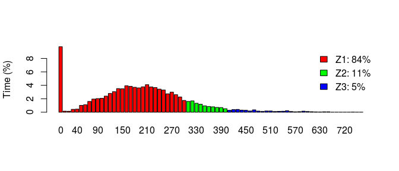

```r
# And plot the above:
zdist_plot(data    = cycling_data,
          column   = power.W,
          zbounds  = c(300, 400))
```

These analyses are made possible by the function `zone_index()`, which generates a zone identifier column for a numeric vector according to supplied boundaries. This identifier can then be used for factor-wise operations (i.e. `tapply()`). This will be useful for those wanting to conduct heart rate zone analyses etc.

## Creating Sections by Stoppages

A common scenario is that we want to partition a ride according to breaks in the data - that is, stops or time periods for which nothing was recorded. For example, the beginning of a race might be neutralised, and hence we want to exclude this from our retrospective analysis. One way to do so might be to scroll through the `timer.s` values in our formatted data and find the break of interest, after which we would subset the data to omit this neutralised region. Or, more efficiently, scroll down the delta time (`delta.t`) values to find the atypical values, and thus stops. The latter is performed by `diff_section()`. This is perhaps best explained by way of example.

```r
# A hypothetical, and tragically short, 1 minute ride.
timer.s <- 1:60
diff_section(timer.s)
```

```
##  [1] 1 1 1 1 1 1 1 1 1 1 1 1 1 1 1 1 1 1 1 1 1 1 1 1 1 1 1 1 1 1 1 1 1 1 1
## [36] 1 1 1 1 1 1 1 1 1 1 1 1 1 1 1 1 1 1 1 1 1 1 1 1 1
```

```r
# A similiarly tragic ride, but now with a 1 minute cafe stop.
timer.s <- c(1:60, 120:180)
diff_section(timer.s)
```

```
##   [1] 1 1 1 1 1 1 1 1 1 1 1 1 1 1 1 1 1 1 1 1 1 1 1 1 1 1 1 1 1 1 1 1 1 1 1
##  [36] 1 1 1 1 1 1 1 1 1 1 1 1 1 1 1 1 1 1 1 1 1 1 1 1 1 2 2 2 2 2 2 2 2 2 2
##  [71] 2 2 2 2 2 2 2 2 2 2 2 2 2 2 2 2 2 2 2 2 2 2 2 2 2 2 2 2 2 2 2 2 2 2 2
## [106] 2 2 2 2 2 2 2 2 2 2 2 2 2 2 2 2
```

```r
# Applied to an *actual* ride:
cycling_data$stop_sections <- diff_section(cycling_data$timer.s)
# How many breaks were there?
unique(cycling_data$stop_sections)
```

```
## [1] 1 2 3 4 5
```

With these section levels appended to the data, it is straightforward to subset the data as desired:

```r
subset(cycling_data, stop_sections == 2)
```

Or perform factor-wise operations:

```r
# Average powers for the 5 sections.
with(cycling_data, tapply(power.W, stop_sections, mean))
```

```
##        1        2        3        4        5
## 233.0274 199.5548 130.0452 188.3177 168.5938
```

## Elapsed Time versus Ride Time

Elapsed time - the time from starting recording to stopping recording, irrespective of stoppages - is easy to calculate from head-unit data:

```r
max(cycling_data$timer.s) / 60  # In minutes.
```

```
## [1] 147.9667
```

However, if you’re interested in time spent actually riding: use `ride_time()`:

```r
ride_time(cycling_data$timer.s) / 60  # In minutes.
```

```
## [1] 145.1667
```

## Mapping

While not formally integrated into this package, a final want of cyclists is the ability to map their ride. Perhaps the easiest way to achieve this is via the package `leaflet`.

```r
# GPS data must be available; and the user must be
# connected to the internet.
# Not Run.
library(leaflet)
leaflet(cycling_data) %>% addTiles() %>% addPolylines(~lng, ~lat)
```

And as simply as that you have an interactive route, as well as all the extended functionality of `leaflet`.

Those are the core functions of this package at this time. Used alongside the standard operations available within R, I hope this package enables useRs to gain much greater insight into their own cycling data.